### AI Project 1 - Pacman Problem

### Hadi Heidari Rad - 810197011

نحوه مدل کردن مسئله به مسئله جستجو:  
فضای حالت مسئله را در قالب یک درخت تصور می کنیم به این صورت که ورودی مسئله وضعیت شروع (initial state) است. عامل های P و Q در هر مرحله حداکثر به 4 جهت بالا، پایین، چپ، و راست می توانند بروند پس در کل هشت Action تعریف می شود. (توجه شود که خوردن غذا برای عامل ها استیت جدیدی نیاز ندارد و فرض می شود که در هر نقطه چه خالی و چه با غذا در حال خوردن هستند! ) پس هر استیت در درخت فضای حالت حداکثر می تواند 8 بچه داشته باشد.  
حالت نهایی (goal state) را حالتی تعریف می کنیم که غذایی در زمین موجود نباشد.

### 1. جستجو BFS

با الگوریتم BFS در درخت فضای حالت بصورت سطح اول پیش می رویم و تا رسیدن به اولین Node ای که جواب باشد، تمام استیت های سطوح قبلی را میبینیم. برای پیاده سازی BFS به یک صف نیاز داریم که در ابتدا نود شامل استیت اولیه به آن اضافه می شود و بعد، تمام بچه هایش و این روند ادامه پیدا می کند تا به اولین جواب برسیم. همچنین نود هایی که یک بار دیده می شوند را در ست visited نگه می داریم تا از رفتن به استیت های تکراری جلوگیری شود.  
کد تابع این جستجو در زیر آورده شده است:

```python
    def bfs(self, start_node):
        global visited_nodes_cnt
        visited = set()
        queue = []
        queue.append(start_node)
        visited.add(start_node.id)
        while queue:
            s = queue.pop(0)
            for each in s.child_maker():
                if each.id not in visited:
                    if is_goal(each):
                        self.print_path(each)
                        visited_nodes_cnt = len(visited)
                        return each
                    queue.append(each)
                    visited.add(each.id)
```

در این الگوریتم با توجه به یکسان بودن همه ی هزینه ها، اولین جواب جواب بهینه است. (چون در کمترین عمق پیدا شده است)

### 2. جستجو IDS

در این الگوریتم بصورت iterative جستجو های DFS ولی با عمق محدود می زنیم. که در اینجا از عمق 1 شروع می کنیم و تا رسیدن به goal state یک واحد یک واحد افزایش می دهیم.  
همچنین با توجه به اینکه اول عمق دیده میشود، برای رسیدن به جواب بهینه، باید در کنار نود های visited عدد cost آنهارا نیز نگه داریم که اگر به نود تکراری ای با مسیر کوتاه تر رسیدیم، نود جدید انتخاب و جایگزین شود.  
تابع dldfs جستجو DFS با عمق محدود انجام می دهد و تابع ids محدودیت حداکثر عمق را تا رسیدن به جواب افزایش می دهد:

```python
    def dldfs(self, start_node, max_depth):
        global visited_nodes_cnt
        visited = {}
        stack = []
        stack.append([start_node, 1])
        visited[start_node.id] = start_node.cost
        while stack:
            node, depth = stack.pop()
            if is_goal(node):
                self.print_path(node)
                visited_nodes_cnt = len(visited)
                return node
            if depth == max_depth:
                continue
            else:
                for each in node.child_maker():
                    if each.id not in visited:
                        stack.append([each, depth + 1])
                        visited[each.id] = each.cost
                    elif (each.id in visited) and (each.cost < visited[each.id]):
                        visited[each.id] = each.cost
                        stack.append([each, depth + 1])
        return False

    def ids(self, start_node):
        max_depth = 1
        while True:
            goal_node = self.dldfs(start_node, max_depth)
            if goal_node is False:
                max_depth += 1
            else:
                return goal_node
```

### 3. جستجو *A

هدف از این الگوریتم جهت دادن به expand شدن نود ها در BFS (در جهتی که بصورت تخمینی به goal state نزدیک تر اند) است. برای اینکار برای هر نود تابع f(n) را بصورت زیر تعریف می کنیم:

f(n) = g(n) + h(n)

که g(n) مقدار هزینه صرف شده برای رسیدن به نود n و h(n) –که تابع heuristic نام دارد– مقدار تخمینی هزینه ی رفتن از نود n تا نود جواب است. هدف این است که در هر مرحله، از میان نود های frontier آن نودی که مقدار f برایش کمینه است را انتخاب کنیم.

تابع heuristic گرفته شده: تعداد غذا های باقی مانده در زمین  
توجیح admissible بودن: می دانیم مینیمم هزینه ممکن برای خوردن یک غذا، یک واحد است. کمترین هزینه و بیشترین غذا زمانی حاصل می شود که غذا ها در خطی افقی یا عمودی کنار هم و عامل هم کنار آنها حضور داشته باشد که در این حالت (worst case) هزینه صرف شده مساوی تخمین heuristic آن استیت می شود. و در بقیه حالات واضحا تخمین heuristic از هزینه واقعی کمتر است. پس این تابع هیچگاه overestimate نمی کند و تخمین حالت نهایی نیز صفر است پس admissible است.  
همچنین طبق قضیه می دانیم شرط لازم و کافی برای بهینه بودن *A روی یک درخت admissible بودن h(n) آن، و روی یک گراف consistent بودن h(n) آن است و با توجه به اینکه فضای حالت ما یک درخت است (و visited ها همچنین ignore می شوند) نتیجه می گیریم که الگوریتممان بهینه است.

```python
    def astar(self, start_node):
        global visited_nodes_cnt
        visited = set()
        frontier = []
        heapq.heappush(frontier, [self.f(start_node, 0), start_node])
        heapq.heapify(frontier)
        visited.add(start_node.id)
        while frontier:
            val, node = heapq.heappop(frontier)
            for each in node.child_maker():
                if each.id not in visited:
                    if is_goal(each):
                        visited_nodes_cnt = len(visited)
                        return each
                    heapq.heappush(frontier, [self.f(each, each.cost), each])
                    visited.add(each.id)

    def f(self, node, cost_up_to_now):
        return node.foods_count + cost_up_to_now
```

#### جدول ها:

##### Test 1

|  | فاصله جواب | تعداد استیت های دیده شده | تعداد استیت های مجزا دیده شده | زمان اجرا |
| --- | --- | --- | --- | --- |
| BFS | 33 | 668729 | 146579 | 102.12 |
| IDS | 33 | 2392839 | 146168 | 3103.97 |
| A* Search | 33 | 558366 | 125114 | 87.01 |

##### Test 2

|  | فاصله جواب | تعداد استیت های دیده شده | تعداد استیت های مجزا دیده شده | زمان اجرا |
| --- | --- | --- | --- | --- |
| BFS | 17 | 15053 | 3565 | 1.16 |
| IDS | 17 | 29232 | 3608 | 10.61 |
| A* Search | 17 | 10189 | 2625 | 0.79 |

##### Test 3

|  | فاصله جواب | تعداد استیت های دیده شده | تعداد استیت های مجزا دیده شده | زمان اجرا |
| --- | --- | --- | --- | --- |
| BFS | 20 | 10340 | 2676 | 1.90 |
| IDS | 20 | 20496 | 2586 | 28.77 |
| A* Search | 20 | 8178 | 2173 | 1.49 |

##### Test 4

|  | فاصله جواب | تعداد استیت های دیده شده | تعداد استیت های مجزا دیده شده | زمان اجرا |
| --- | --- | --- | --- | --- |
| BFS | 17 | 51697 | 11502 | 19.70 |
| IDS | 17 | 76815 | 9464 | 150.56 |
| A* Search | 17 | 34672 | 8181 | 13.32 |

##### Test 5

|  | فاصله جواب | تعداد استیت های دیده شده | تعداد استیت های مجزا دیده شده | زمان اجرا |
| --- | --- | --- | --- | --- |
| BFS | 13 | 1015 | 331 | 0.087 |
| IDS | 13 | 1079 | 226 | 0.641 |
| A* Search | 13 | 693 | 235 | 0.055 |

##### مقایسه الگوریتم ها با هم:

BFS تمام استیت های موجود در درخت را تا زمان رسیدن به اولین جواب به صورت اول سطح می بیند. به این صورت که ابتدا تمام استیت های یک سطح تمام می شود و بعد سراغ سطح بعدی می رود. پس با توجه به یونیفورم بودن درخت، اولین جواب پیدا شده با این الگوریتم، جواب بهینه است. عیب این الگوریتم، کورکورانه بودن آن است و تمام نود های اطراف خود را بدون توجه به محتمل بودن رسیدن یا نرسیدن آن به جواب، expand می کند که باعث افزایش مصرف زمان و حافظه می شود.  
IDS با عمق های محدود و iterative الگوریتم DFS را اجرا می کند، در واقع DFS را به روش BFS بصورت ترتیبی انجام می دهد که در حالت کلی منجر به خطی شدن حافظه می شود اما زمان اجرای آن در عمل بد تر از BFS می شود. (چون برای سطوح مختلف کارهای تکراری انجام می شوند)  
نکته: برای آنکه IDS جواب بهینه بدهد باید علاوه بر نگه داشتن visited ها، هزینه ی آنهارا نیز نگه داشت، دلیل هم آن است که هنگام دیدن عمق و بازگشت به سطح های قبلتر ممکن است مسیر کوتاه تری برای رسیدن به یک نود مشخص پیدا کنیم که در این صورت باید نود جدید را انتخاب و جایگزین کنیم.  
*A نسخی ی informed ای از الگوریتم BFS است به این صورت که با تخمینی از هزینه ی آینده، تصمیم میگیریم کدام مسیر هارا expand بکنیم یا نکنیم، این رویکرد باعث کاهش زمان صرف شده برای رسیدن به جواب می شود. که در اعداد ثبت شده در جدول نیز قابل مشاهده است.

##### نمودار های زمان اجرا بر حسب فاصله از جواب به تفکیک الگوریتم:

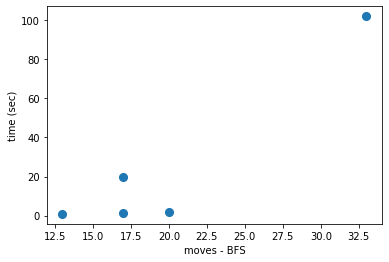

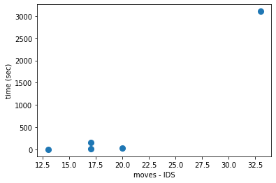

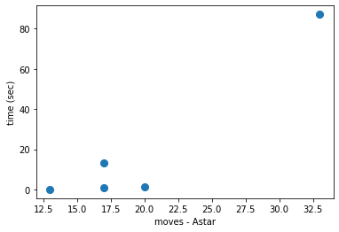

```python
import matplotlib.pyplot as plt

bfs_data_x = [13, 17, 17, 20, 33]
bfs_data_y = [0.87, 1.16, 19.7, 1.9, 102]
plt.scatter(bfs_data_x, bfs_data_y, s = 65)
plt.xlabel('moves - BFS')
plt.ylabel('time (sec)')
plt.show()

ids_data_x = [13, 17, 17, 20, 33]
ids_data_y = [0.641, 10.61, 150.56, 28.77, 3103]
plt.scatter(ids_data_x, ids_data_y, s = 65)
plt.xlabel('moves - IDS')
plt.ylabel('time (sec)')
plt.show()

astar_data_x = [13, 17, 17, 20, 33]
astar_data_y = [0.055, 0.79, 13.32, 1.49, 87.01]
plt.scatter(astar_data_x, astar_data_y, s = 65)
plt.xlabel('moves - Astar')
plt.ylabel('time (sec)')
plt.show()
```

یک نکته اضافه:  
در حین زدن Astar متوجه شدم اگر تابع f(n) را برابر h(n) قرار دهم، سرعت اجرا به مقدار خیلی زیادی افزایش پیدا می کند و نود های دیده شده هم به شدت کمتر می شوند و جواب درست و نزدیک به بهینه ای نمایش داده می شود، برای مثال تست کیس ۱ با زمان کمتر از ۱ ثانیه و تعداد نود های ویزیتد 1054 عدد به جواب می رسد! (این جواب برای همه ی تست ها بهینه نبود و با جواب astar معمولی که زدم فرق داشت اما خیلی شبیه به بهینه بود و حرکت بی معنی ای انجام نمی شد.) این تابع را نیز در کدم به نام تابع another_astar آورده ام. (نام نسخه ی اصلی در کد astar است).